# part2__attririon_modeling

## Introduction

This notebook loads the data from the R script (which contains the information from the surveys and demographics combined into a single table). Using this data, we try to build several models to predict the likelihood of an employee leaving voluntarily in the coming months.

The primary goal is to use the output of the model to identify employees that are at risk of leaving and build targetted retention plan or packages for them. This plan could include things like long term stock incentives, possibility of career growth throgh promotion or more responsibilities. It could further be fine tuned based on whether the empployee is high performance/high potential or not. Foe example, if a low perfomance/low potetial employee is likely to leave voluntarily, a retention program may not be needed.

By proactively identifying employees likely to leave voluntarily and creating an action plan to retain them, the compnay could save a substantial amount of money in the long run.

## Model Development

This section includes some technical details about how the model(s) were developed. Skip to the Conclusion section for summary.

The Dataset is highly imbalanced. Initially, the model was built with the original data "as-is" with only a balanced weight used in the model development. But with this approach, the models were overpredicting the likelihood of non attrition so it did not meet the original objective.

After various combinations of techniques, the one that gave the best results was the one that oversampled the "attrition" class level (using SMOTE) just for the training. This gave a better result that approaches without oversampling.

Two (2) models were tried for this initial analysis - Support Vector Machines and Random Forest Classifiers. This included a baseline model with default parameters and a tuned model with hyperparameter optimization. The best results were obtained using the Baseline Support Vector Machine model.

## Conclusion

While the best model developed performed better than random guessing, it is not good enough yet to put into production. The model still only correctly predicts 1 in 3 people that will leave and overestimates 5 employees that will leave (but dont) for every 1 employee that is correctly identified as leaving. Nonetheless this is an important step in the roadmap to reduce attrition. Some ways to improve the model performance are suggested below.

- The dataset did not contain some important features that can impact attrition such as pending incentives that the employee has. Getting access to this data would likely improve the model's performance.
- The output of the model should not be the sole point of reference that is used to decide whether an employee is likely to leave. This should serve as one reference point, and other reference points must be gathered to triangualte on the employees that are actually likely to leave. For example, the model incorrectly predicts that 5 employees will leave for every 1 employee that actually leaves. However, some of these 5 employees could be eliminated from the list of high attrition employees (for example, by looking at employees that have high pending stock incentives), then we could narrow down the list to more likelt candidates.

```python
import numpy as np
import pandas as pd
import matplotlib.pyplot as plt
%matplotlib inline
plt.style.use('ggplot')
```

```python
data = pd.read_csv("../data/data_combined.csv", encoding='latin-1')
data.info()
```

```
<class 'pandas.core.frame.DataFrame'>
RangeIndex: 18999 entries, 0 to 18998
Data columns (total 89 columns):
 #   Column                                  Non-Null Count  Dtype
---  ------                                  --------------  -----
 0   PersonID                                18999 non-null  object
 1   Engagement Level                        18999 non-null  object
 2   EN0330                                  18999 non-null  int64
 3   EN0190                                  18999 non-null  int64
 4   EN0012                                  18999 non-null  int64
 5   EN0094                                  18999 non-null  int64
 6   EN0027                                  18999 non-null  int64
 7   EN0017                                  18999 non-null  int64
 8   EN0002                                  18999 non-null  int64
 9   EN0026                                  18999 non-null  int64
```

[output cut: 81 more lines]

```python
# Survey Responses
cols_to_keep_survey = data.columns[data.columns.str.startswith('EN', na=False)]
cols_to_keep_survey = cols_to_keep_survey.append(data.columns[data.columns.str.startswith('CU', na=False)])
cols_to_keep_survey.values
```

```
array(['EN0330', 'EN0190', 'EN0012', 'EN0094', 'EN0027', 'EN0017',
       'EN0002', 'EN0026', 'EN0248', 'EN0415', 'EN0036', 'EN0007',
       'EN0005', 'EN0066', 'EN0078', 'EN0015', 'EN0043', 'EN0028',
       'EN0103', 'EN0092', 'EN0247', 'EN0395', 'EN0199', 'EN0337',
       'EN0231', 'EN0001', 'EN0014', 'EN0193', 'EN0230', 'EN0319',
       'EN0187', 'EN0111', 'EN0081', 'EN0349', 'EN0006', 'EN0163',
       'EN0080', 'EN0232', 'EN0049', 'EN0053', 'EN0003', 'EN0075',
       'EN0024', 'EN0151', 'EN0397', 'EN0100', 'EN0004', 'EN0108',
       'EN0363', 'CU0001', 'CU0002', 'CU0003', 'CU0004', 'CU0005',
       'CU0006', 'CU0008', 'CU0009', 'CU0010', 'CU0011', 'CU0012'],
      dtype=object)
```

```python
# Demographics
cols_to_keep_dem = [
    'State', 'Country', 'Exempt Status', 'Gender', 'RaceEthnicity', 'WFH',
    'PeopleLeader', 'SalesFunction', 'MgtLvlDetailed', 'HIPO', 'MgrChg1yr',
    'JobChg1yr', 'JobLvlChg1yr', 'Promoted1yr', 'Business Unit', 'Language'
]

col_output = ['VoluntaryAttrition']
```

```python
cols_to_keep = cols_to_keep_survey.to_list() + col_output
add_dem_cols = True # False = Only use survey output as features, True = Survey Output + Selected Demographic Data
if add_dem_cols:
    cols_to_keep = cols_to_keep + cols_to_keep_dem
print(cols_to_keep)
```

```
['EN0330', 'EN0190', 'EN0012', 'EN0094', 'EN0027', 'EN0017', 'EN0002', 'EN0026', 'EN0248', 'EN0415', 'EN0036', 'EN0007', 'EN0005', 'EN0066', 'EN0078', 'EN0015', 'EN0043', 'EN0028', 'EN0103', 'EN0092', 'EN0247', 'EN0395', 'EN0199', 'EN0337', 'EN0231', 'EN0001', 'EN0014', 'EN0193', 'EN0230', 'EN0319',…
```

```python
data_subset = data[cols_to_keep].copy(deep=True)
```

### One Hot Encoding

```python
categorical_features = data_subset[cols_to_keep].select_dtypes(include='object').columns
for column in categorical_features:
    if column in data_subset.columns:
        print ("The number of levels in column '{}': {}".format(column,data_subset[column].nunique()))
```

```
The number of levels in column 'State': 26
The number of levels in column 'Country': 29
The number of levels in column 'Exempt Status': 2
The number of levels in column 'Gender': 3
The number of levels in column 'RaceEthnicity': 7
The number of levels in column 'SalesFunction': 4
The number of levels in column 'MgtLvlDetailed': 6
The number of levels in column 'HIPO': 3
The number of levels in column 'MgrChg1yr': 2
The number of levels in column 'JobChg1yr': 2
The number of levels in column 'JobLvlChg1yr': 3
The number of levels in column 'Promoted1yr': 2
The number of levels in column 'Business Unit': 11
The number of levels in column 'Language': 15
```

```python
cat_features_present = len(categorical_features) > 0
cat_features_present
```

```
True
```

```python
if cat_features_present:
    cat_with_dummies = pd.get_dummies(data_subset[categorical_features], drop_first=True)
    cat_with_dummies.info()
```

```
<class 'pandas.core.frame.DataFrame'>
RangeIndex: 18999 entries, 0 to 18998
Columns: 101 entries, State_AK to Language_Thai
dtypes: uint8(101)
memory usage: 1.8 MB
```

```python
if cat_features_present:
    # replace categorical columns with OHE data
    data_subset.drop(categorical_features,axis=1,inplace=True)
    data_subset = pd.concat([data_subset, cat_with_dummies],axis=1)
    data_subset.info()
```

```
<class 'pandas.core.frame.DataFrame'>
RangeIndex: 18999 entries, 0 to 18998
Columns: 164 entries, EN0330 to Language_Thai
dtypes: int64(63), uint8(101)
memory usage: 11.0 MB
```

```python
# we want to predict the X and y data as follows:
if 'VoluntaryAttrition' in data_subset:
    y = data_subset['VoluntaryAttrition'].values # get the labels we want
    del data_subset['VoluntaryAttrition'] # get rid of the class label
    X = data_subset.values # use everything else to predict!
    dataColNames = data_subset.columns
```

```python
print(data.shape)
print(len(cols_to_keep))
print(X.shape)
print(y.shape)
```

```
(18999, 89)
77
(18999, 163)
(18999,)
```

```python
# Data Splitting
from sklearn.model_selection import train_test_split
from sklearn.model_selection import ShuffleSplit
from sklearn.model_selection import StratifiedKFold
from sklearn.model_selection import StratifiedShuffleSplit  # Only applicable for classification problem

# Preprocessing and Pipeline
from sklearn.preprocessing import StandardScaler
from sklearn.pipeline import Pipeline

# Oversampling
from imblearn.over_sampling import SMOTE

# Models
from sklearn.linear_model import LogisticRegression
from sklearn.linear_model import SGDClassifier
from sklearn.svm import SVC
from sklearn.svm import LinearSVC
from sklearn.ensemble import RandomForestClassifier
from sklearn.neighbors import KNeighborsClassifier

# Model Diagnosis
from sklearn.model_selection import validation_curve
from sklearn.model_selection import learning_curve
from sklearn.model_selection import GridSearchCV
from sklearn.model_selection import cross_validate

# Scoring
from sklearn.metrics import f1_score, recall_score, accuracy_score, precision_score, mean_squared_error, make_scorer
from sklearn.metrics import plot_confusion_matrix
from sklearn.model_selection import cross_val_score
from sklearn import metrics as mt

# For hyperparameter optimization
from skopt.space import Integer, Categorical, Real
from skopt.utils import use_named_args
from skopt import gp_minimize
import skopt.plots
```

```python
per_minority = sum(y == 1)/len(y)
per_minority
```

```
0.03158060950576346
```

```python
# Split test set before potentially ovrsampling  (this avoids leakage into test data)
X_train, X_test, y_train, y_test = train_test_split(X, y, test_size=0.2, random_state=42)
```

```python
use_smote = True
```

```python
if use_smote:
    # Oversample to take care of class imbalance
    smote = SMOTE(sampling_strategy ='minority', random_state=42, n_jobs=-1)
    X_train, y_train = smote.fit_sample(X_train, y_train)
```

```python
test_per_minority = sum(y_test == 1)/len(y_test)
print(f"Test Data (features): {X_test.shape}")
print(f"Test Data (labels): {y_test.shape}; Percentage of Minority Class: {test_per_minority}")

print("\n")
if use_smote:
    print("Using Smote (oversampling) ...")

print(f"\tTrain Data (features): {X_train.shape}")
print(f"\tTrain Data (labels): {y_train.shape}")
per_minority_train = sum(y_train == 1)/len(y_train)
print(f"Change in percent of minority class in Train Data: {round(per_minority,3)} --> {per_minority_train}")
```

```
Test Data (features): (3800, 163)
Test Data (labels): (3800,); Percentage of Minority Class: 0.035


Using Smote (oversampling) ...
	Train Data (features): (29464, 163)
	Train Data (labels): (29464,)
Change in percent of minority class in Train Data: 0.032 --> 0.5
```

```python
per_majority_train = (1-per_minority_train)
wt_majority = per_minority_train
wt_minority = per_majority_train

# class_weight='balanced'
# class_weight='balanced_subsample'
class_weight = {0:wt_majority, 1:wt_minority}
class_weight
```

```
{0: 0.5, 1: 0.5}
```

```python
scoring = {
    'recall_attrited_only': make_scorer(recall_score, average='binary'), # Positive Class Only
    'precision_attrited_only': make_scorer(precision_score, average='binary'), # Positive Class Only
    'f1_attrited_only': make_scorer(f1_score, average='binary'), # Positive Class Only
    'f1_weighted': make_scorer(f1_score, average='weighted')
}
```

```python
## Sourcing the .py
t='common_functions.py'
%run -i $t
```

```python
num_cv_iterations = 3

cv_object = StratifiedShuffleSplit(
    n_splits=num_cv_iterations,
    test_size  = 0.2,
    random_state = 101
)

print(cv_object)
```

```
StratifiedShuffleSplit(n_splits=3, random_state=101, test_size=0.2,
            train_size=None)
```

## Support Vector Machine Model

### Baseline Model

```python
# Baseline SVM model
regularize_const = 0.1
iterations = 5
svm_sgd = SGDClassifier(alpha=regularize_const
                        #,class_weight='balanced'
                        ,class_weight=class_weight
                        ,fit_intercept=True
                        ,l1_ratio=0.0
                        ,learning_rate='optimal'
                        ,loss='hinge'
                        ,n_iter_no_change=iterations
                        ,n_jobs=-1
                        ,penalty='l2'
                        ,random_state=101
                       )

std_scl = StandardScaler()

piped_object = Pipeline([
    ('scale', std_scl),  # do this
    ('svm_model', svm_sgd)] # and then do this
)
```

```python
piped_object.fit(X_train, y_train)
```

```
Pipeline(steps=[('scale', StandardScaler()),
                ('svm_model',
                 SGDClassifier(alpha=0.1, class_weight={0: 0.5, 1: 0.5},
                               l1_ratio=0.0, n_jobs=-1, random_state=101))])
```

```
[('Confusion matrix, without normalization', None)]
Confusion matrix, without normalization
```

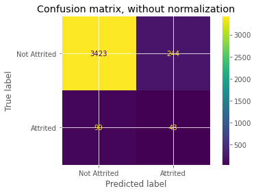

```
              precision    recall  f1-score   support

           0       0.97      0.93      0.95      3667
           1       0.15      0.32      0.20       133

    accuracy                           0.91      3800
   macro avg       0.56      0.63      0.58      3800
weighted avg       0.95      0.91      0.93      3800
```

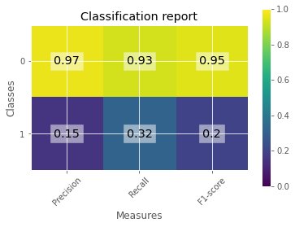

```python
print_classification_details(
    clf=piped_object,
    X_test=X_test, y_test=y_test,
    display_labels=["Not Attrited", "Attrited"],
    verbose=True
)
```

### Tuned Model

```python
## https://scikit-optimize.github.io/notebooks/visualizing-results.html

# set up hyperparameter space
space = [
    Real(1e-5, 1e-0, name='alpha', prior='log-uniform'),
    Real(10e2, 10e6, name='max_iter',prior='log-uniform'), # needs an integer but that does not have log-normal sampling. Hence using Real (algorith works with real as well)
    Integer(3,7,name='n_iter_no_change')
]

# Object to scale the inputs before training
std_scl = StandardScaler()

@use_named_args(space)
def objective(**params):
    svm_sgd = SGDClassifier(learning_rate = 'optimal'
                            #,class_weight = 'balanced'
                            ,class_weight=class_weight
                            ,loss = 'hinge'
                            ,n_jobs = -1
                            ,random_state = 101
                            ,**params)

    piped_object = Pipeline([('scale', std_scl),  # do this
                             ('svm_model', svm_sgd)]) # and then do this

    # Get all metrics and define custom loss function using this data
    cv_results = cross_validate(piped_object, X_train, y_train, cv=cv_object, scoring = scoring)
    # loss = -np.mean(cv_results['test_recall_promoted_only'] + cv_results['test_f1_weighted'])
    # loss = -np.mean(cv_results['test_recall_attrited_only'] + cv_results['test_f1_attrited_only'])
    loss = -np.mean(
        cv_results['test_recall_attrited_only'] + \
        cv_results['test_precision_attrited_only']
    )

    return (loss)
```

```python
clf_gp = gp_minimize(
    objective,
    space,
    n_random_starts=10, # 10 random points to start
    n_calls=25, # pick 25 points total (including n_random_starts) to define optimal combination of hyperparameters
    verbose=True,
    n_jobs=-1,
    random_state=101,
)
```

```
Iteration No: 1 started. Evaluating function at random point.
Iteration No: 1 ended. Evaluation done at random point.
Time taken: 0.9392
Function value obtained: -1.8867
Current minimum: -1.8867
Iteration No: 2 started. Evaluating function at random point.
Iteration No: 2 ended. Evaluation done at random point.
Time taken: 2.5400
Function value obtained: -1.8813
Current minimum: -1.8867
Iteration No: 3 started. Evaluating function at random point.
Iteration No: 3 ended. Evaluation done at random point.
Time taken: 0.8884
Function value obtained: -1.8824
Current minimum: -1.8867
Iteration No: 4 started. Evaluating function at random point.
Iteration No: 4 ended. Evaluation done at random point.
Time taken: 0.8380
Function value obtained: -1.8277
Current minimum: -1.8867
Iteration No: 5 started. Evaluating function at random point.
Iteration No: 5 ended. Evaluation done at random point.
Time taken: 2.8652
Function value obtained: -1.8759
Current minimum: -1.8867
Iteration No: 6 started. Evaluating function at random point.
Iteration No: 6 ended. Evaluation done at random point.
Time taken: 0.9652
Function value obtained: -1.8815
Current minimum: -1.8867
Iteration No: 7 started. Evaluating function at random point.
Iteration No: 7 ended. Evaluation done at random point.
Time taken: 0.8396
Function value obtained: -1.8765
Current minimum: -1.8867
Iteration No: 8 started. Evaluating function at random point.
Iteration No: 8 ended. Evaluation done at random point.
Time taken: 0.8053
Function value obtained: -1.8533
Current minimum: -1.8867
```

[output cut: 70 more lines]

```
Iteration No: 23 started. Searching for the next optimal point.
Iteration No: 23 ended. Search finished for the next optimal point.
Time taken: 1.4883
Function value obtained: -1.8910
Current minimum: -1.8981
Iteration No: 24 started. Searching for the next optimal point.
Iteration No: 24 ended. Search finished for the next optimal point.
Time taken: 1.6871
Function value obtained: -1.9002
Current minimum: -1.9002
Iteration No: 25 started. Searching for the next optimal point.
Iteration No: 25 ended. Search finished for the next optimal point.
Time taken: 2.0213
Function value obtained: -1.8937
Current minimum: -1.9002
```

```python
# Model with best hyperparameters
# Object to scale the inputs before training
std_scl = StandardScaler()

svm_sgd = SGDClassifier(alpha = clf_gp.x[0]
                        #,class_weight = 'balanced'
                        ,class_weight=class_weight
                        ,fit_intercept=True
                        ,l1_ratio=0.0
                        ,learning_rate='optimal'
                        ,loss='hinge'
                        ,max_iter=clf_gp.x[1]
                        ,n_iter_no_change= clf_gp.x[2]
                        ,n_jobs = -1
                        ,penalty='l2'
                        ,verbose=0
                        ,random_state = 101
                        )

piped_object = Pipeline([
    ('scale', std_scl),  # do this
    ('svm_model', svm_sgd)] # and then do this
)
```

```python
piped_object.fit(X_train, y_train)
```

```
Pipeline(steps=[('scale', StandardScaler()),
                ('svm_model',
                 SGDClassifier(alpha=0.0004088773368860969,
                               class_weight={0: 0.5, 1: 0.5}, l1_ratio=0.0,
                               max_iter=1221.8355500297293, n_iter_no_change=7,
                               n_jobs=-1, random_state=101))])
```

```
[('Confusion matrix, without normalization', None)]
Confusion matrix, without normalization
```

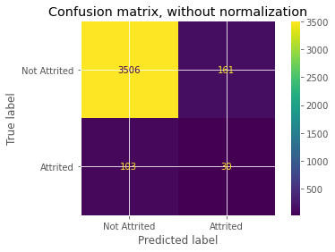

```
              precision    recall  f1-score   support

           0       0.97      0.96      0.96      3667
           1       0.16      0.23      0.19       133

    accuracy                           0.93      3800
   macro avg       0.56      0.59      0.57      3800
weighted avg       0.94      0.93      0.94      3800
```

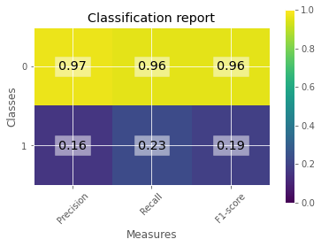

```python
print_classification_details(
    clf=piped_object,
    X_test=X_test, y_test=y_test,
    display_labels=["Not Attrited", "Attrited"],
    verbose=True
)
```

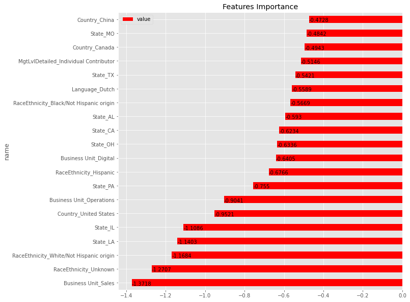

```python
varImpSVM(piped_object.named_steps['svm_model'], 20, dataColNames)
```

## Random Forest

### Baseline Model

```python
# Baseline Random Forest model
rf_std = RandomForestClassifier( n_estimators=500
                                , max_depth=None
                                , min_samples_split=20
                                , min_samples_leaf=20
                                , n_jobs=-1
                                # , class_weight='balanced'
                                , class_weight=class_weight
                                , random_state = 101 )

piped_object = Pipeline([('rf_model', rf_std)])
```

```python
piped_object.fit(X_train, y_train)
```

```
Pipeline(steps=[('rf_model',
                 RandomForestClassifier(class_weight={0: 0.5, 1: 0.5},
                                        min_samples_leaf=20,
                                        min_samples_split=20, n_estimators=500,
                                        n_jobs=-1, random_state=101))])
```

```
[('Confusion matrix, without normalization', None)]
Confusion matrix, without normalization
```

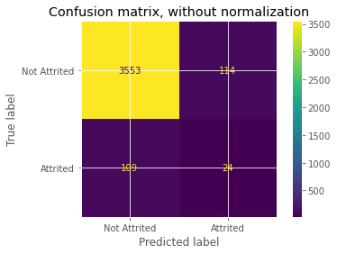

```
              precision    recall  f1-score   support

           0       0.97      0.97      0.97      3667
           1       0.17      0.18      0.18       133

    accuracy                           0.94      3800
   macro avg       0.57      0.57      0.57      3800
weighted avg       0.94      0.94      0.94      3800
```

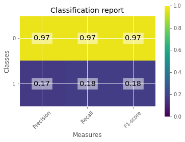

```python
print_classification_details(
    clf=piped_object,
    X_test=X_test, y_test=y_test,
    display_labels=["Not Attrited", "Attrited"],
    verbose=True
)
```

### Tuned Model

```python
# set up hyperparameter space
space = [Integer(100, 1000, name='n_estimators')#, prior='log-uniform')
         ,Integer(10, 1000, name='max_depth')#, prior='log-uniform')
         ,Real(0.000001, 0.1, name='min_samples_split', prior='log-uniform')
         ,Real(0.000001, 0.1, name='min_samples_leaf', prior='log-uniform')
        ]

@use_named_args(space)
def objective(**params):
    rf_std  =RandomForestClassifier(n_jobs=-1
                                   , random_state = 101
                                   # , class_weight='balanced'
                                   , class_weight=class_weight
                                   ,**params)

    piped_object = Pipeline([('rf_model', rf_std)])

    # Get all metrics and define custom loss function using this data
    cv_results = cross_validate(piped_object, X_train, y_train, cv=cv_object, scoring = scoring)
    # loss = -np.mean(cv_results['test_recall_promoted_only'] + cv_results['test_f1_weighted'])
    # loss = -np.mean(cv_results['test_recall_attrited_only'] + cv_results['test_f1_attrited_only'])
    loss = -np.mean(
        cv_results['test_recall_attrited_only'] + \
        cv_results['test_precision_attrited_only']
    )

    return (loss)
```

```python
clf_gp = gp_minimize(objective
                     ,space
                     ,n_random_starts=10 # 10 random points to start
                     ,n_calls=25 # pick 25 points total (including n_random_starts) to define optimal combination of hyperparameters
                     ,verbose=True
                     ,n_jobs=-1
                     ,random_state=101
                    )
```

```
Iteration No: 1 started. Evaluating function at random point.
Iteration No: 1 ended. Evaluation done at random point.
Time taken: 22.5416
Function value obtained: -1.6920
Current minimum: -1.6920
Iteration No: 2 started. Evaluating function at random point.
Iteration No: 2 ended. Evaluation done at random point.
Time taken: 32.1118
Function value obtained: -1.9626
Current minimum: -1.9626
Iteration No: 3 started. Evaluating function at random point.
Iteration No: 3 ended. Evaluation done at random point.
Time taken: 31.3259
Function value obtained: -1.6575
Current minimum: -1.9626
Iteration No: 4 started. Evaluating function at random point.
Iteration No: 4 ended. Evaluation done at random point.
Time taken: 8.5652
Function value obtained: -1.9003
Current minimum: -1.9626
Iteration No: 5 started. Evaluating function at random point.
Iteration No: 5 ended. Evaluation done at random point.
Time taken: 23.4386
Function value obtained: -1.4982
Current minimum: -1.9626
Iteration No: 6 started. Evaluating function at random point.
Iteration No: 6 ended. Evaluation done at random point.
Time taken: 20.5117
Function value obtained: -1.6587
Current minimum: -1.9626
Iteration No: 7 started. Evaluating function at random point.
Iteration No: 7 ended. Evaluation done at random point.
Time taken: 13.5338
Function value obtained: -1.9519
Current minimum: -1.9626
Iteration No: 8 started. Evaluating function at random point.
Iteration No: 8 ended. Evaluation done at random point.
Time taken: 32.3270
Function value obtained: -1.8393
Current minimum: -1.9626
```

[output cut: 70 more lines]

```
Iteration No: 23 started. Searching for the next optimal point.
Iteration No: 23 ended. Search finished for the next optimal point.
Time taken: 49.5755
Function value obtained: -1.9733
Current minimum: -1.9740
Iteration No: 24 started. Searching for the next optimal point.
Iteration No: 24 ended. Search finished for the next optimal point.
Time taken: 54.7925
Function value obtained: -1.9733
Current minimum: -1.9740
Iteration No: 25 started. Searching for the next optimal point.
Iteration No: 25 ended. Search finished for the next optimal point.
Time taken: 56.7481
Function value obtained: -1.9667
Current minimum: -1.9740
```

```python
print('Best score: {}'.format(clf_gp.fun))
print('Best params:')
print(clf_gp.x)
```

```
Best score: -1.9740102984436347
Best params:
[100, 1000, 1.9624751776145097e-05, 5.31454986554527e-06]
```

```python
# _ = skopt.plots.plot_objective(clf_gp, size=4, dimensions=['n_estimators','max_depth','min_samples_split','min_samples_leaf'])
```

```python
rf_std = RandomForestClassifier( n_jobs=-1
                                , random_state = 101
                                , n_estimators = clf_gp.x[0]
                                , max_depth = clf_gp.x[1]
                                , min_samples_split =  clf_gp.x[2]
                                , min_samples_leaf =clf_gp.x[3]
                                # , class_weight='balanced'
                                , class_weight=class_weight
                               )

piped_object = Pipeline([('rf_model', rf_std)])
```

```python
piped_object.fit(X_train, y_train)
```

```
Pipeline(steps=[('rf_model',
                 RandomForestClassifier(class_weight={0: 0.5, 1: 0.5},
                                        max_depth=1000,
                                        min_samples_leaf=5.31454986554527e-06,
                                        min_samples_split=1.9624751776145097e-05,
                                        n_jobs=-1, random_state=101))])
```

```
[('Confusion matrix, without normalization', None)]
Confusion matrix, without normalization
```

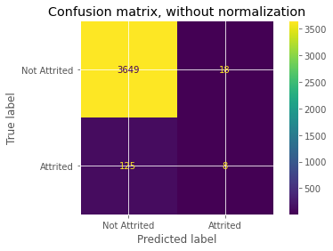

```
              precision    recall  f1-score   support

           0       0.97      1.00      0.98      3667
           1       0.31      0.06      0.10       133

    accuracy                           0.96      3800
   macro avg       0.64      0.53      0.54      3800
weighted avg       0.94      0.96      0.95      3800
```

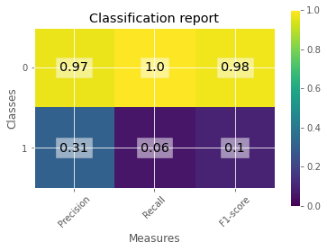

```python
print_classification_details(
    clf=piped_object,
    X_test=X_test, y_test=y_test,
    display_labels=["Not Attrited", "Attrited"],
    verbose=True
)
```

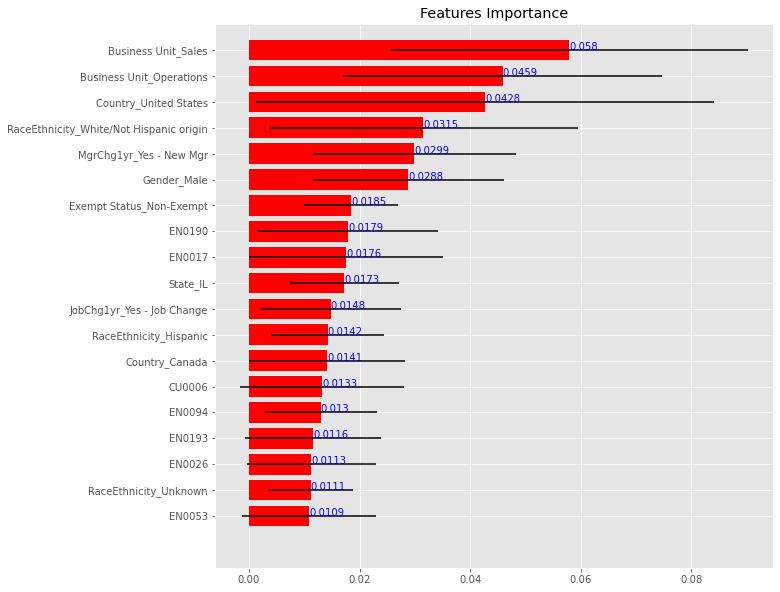

```python
varImpRFStDev(piped_object.named_steps['rf_model'], 20, dataColNames)
```